# IODS course project

Elina Järvelä-Reijonen

# About the project

*Hi, I am both **excited** and a bit **overwhelmed** about the contents of this course! I expect to learn at least the basics about open data, R, and data science. I have started in a new project at our university related to these topics, and that’s where I also heard about this course.*

Here is the link to my GitHub repository

https://github.com/elinaj-r/IODS-project

# RStudio Excercise 2: Regression and model validation

*Describe the work you have done this week and summarize your learning.*

- *Describe your work and results clearly.*
- *Assume the reader has an introductory course level understanding of writing and reading R code as well as statistical methods.*
- *Assume the reader has no previous knowledge of your data or the more advanced methods you are using.*

## Reading data and exploring data

I started with the data wrangling and saved the learning2014.csv into my data-folder. You can find the R script and data here: https://github.com/elinaj-r/IODS-project/tree/master/data.

Here below is the R script and outcomes for reading the data and exploring it:

```r
# Elina Järvelä-Reijonen
# 11.11.2019
# R script for data students2014, data source from own files: IODS-project/data/learning2014.csv

# Reading the data
students2014 = read.csv("~/IODS-project/data/learning2014.csv", header = TRUE, row.names = 1)

# Exploring the structure and dimensions of the data
str(students2014)
```

```
## 'data.frame':    166 obs. of  7 variables:
##  $ gender  : Factor w/ 2 levels "F","M": 1 2 1 2 2 1 2 1 2 1 ...
##  $ age     : int  53 55 49 53 49 38 50 37 37 42 ...
##  $ attitude: num  3.7 3.1 2.5 3.5 3.7 3.8 3.5 2.9 3.8 2.1 ...
##  $ deep    : num  3.58 2.92 3.5 3.5 3.67 ...
##  $ stra    : num  3.38 2.75 3.62 3.12 3.62 ...
##  $ surf    : num  2.58 3.17 2.25 2.25 2.83 ...
##  $ points  : int  25 12 24 10 22 21 21 31 24 26 ...
```

```r
dim(students2014)
```

```
## [1] 166   7
```

**Interpretation:** The dataset includes 166 observations and 7 variables. Thus, for this dataset, 166 students have answered to a questionnaire about their gender, age, attitude, approaches to learning (deep, strategic, surface), and exam points from a statistics course. The gender is a 2-level factor variable (“F”, “M”) and the other variables are numerical.

## Descriptives of the variables

```r
summary(students2014)
```

```
##  gender       age           attitude          deep            stra
##  F:110   Min.   :17.00   Min.   :1.400   Min.   :1.583   Min.   :1.250
##  M: 56   1st Qu.:21.00   1st Qu.:2.600   1st Qu.:3.333   1st Qu.:2.625
##          Median :22.00   Median :3.200   Median :3.667   Median :3.188
##          Mean   :25.51   Mean   :3.143   Mean   :3.680   Mean   :3.121
##          3rd Qu.:27.00   3rd Qu.:3.700   3rd Qu.:4.083   3rd Qu.:3.625
##          Max.   :55.00   Max.   :5.000   Max.   :4.917   Max.   :5.000
##       surf           points
##  Min.   :1.583   Min.   : 7.00
##  1st Qu.:2.417   1st Qu.:19.00
##  Median :2.833   Median :23.00
##  Mean   :2.787   Mean   :22.72
##  3rd Qu.:3.167   3rd Qu.:27.75
##  Max.   :4.333   Max.   :33.00
```

**Interpretation:** There are 110 females and 56 males. They are aged of 17-55, with a mean of 26 years. The students’ exam points range between 7 and 33, with a mean of 23 points.

## Exploring data visually

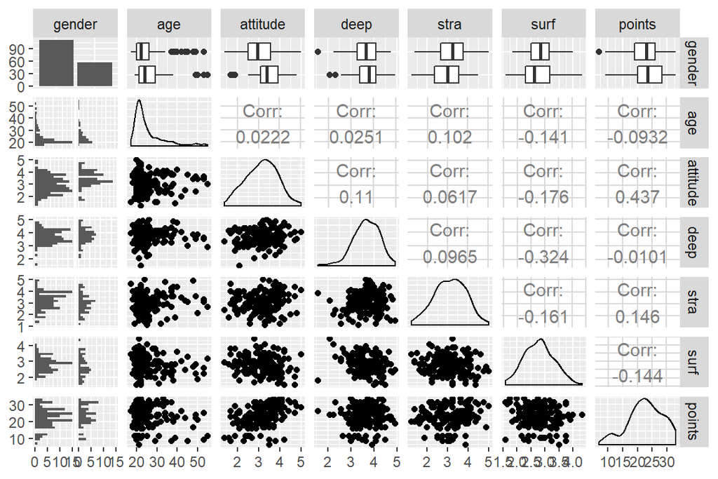

```r
# A graphical overview of the data and summaries of the variables in the data
# Access the GGally and ggplot2 libraries
library(GGally)
library(ggplot2)

# Create a plot matrix
p <- ggpairs(students2014, mapping = aes(), lower = list(combo = wrap("facethist", bins = 20)))

# Draw the plot
p
```

## Regression model

To fit a regression model where exam points is the target (dependent) variable, I choose the three most correlated variables as explanatory (independent) variables.

```r
# Creating the model
my_model <- lm(points ~ attitude + stra + surf, data = students2014)

# Printing the summary
summary(my_model)
```

```
##
## Call:
## lm(formula = points ~ attitude + stra + surf, data = students2014)
##
## Residuals:
##      Min       1Q   Median       3Q      Max
## -17.1550  -3.4346   0.5156   3.6401  10.8952
##
## Coefficients:
##             Estimate Std. Error t value Pr(>|t|)
## (Intercept)  11.0171     3.6837   2.991  0.00322 **
## attitude      3.3952     0.5741   5.913 1.93e-08 ***
## stra          0.8531     0.5416   1.575  0.11716
## surf         -0.5861     0.8014  -0.731  0.46563
## ---
## Signif. codes:  0 '***' 0.001 '**' 0.01 '*' 0.05 '.' 0.1 ' ' 1
##
## Residual standard error: 5.296 on 162 degrees of freedom
## Multiple R-squared:  0.2074, Adjusted R-squared:  0.1927
## F-statistic: 14.13 on 3 and 162 DF,  p-value: 3.156e-08
```

**Interpretation:** The only statistically significant predictor of the exam points is attitude (p<.001). The estimate shows that if attitude increases one point, exam points would increase 3.4 points. The estimate of the intercept shows that if attitude score is zero, exam points would be 11.0.Strategic learning approach have a positive estimate, meaning that it may have some positive association with exam points, but that is not statistically significant (p=.117). Surface learning approach may have some negative association with exam points, but also that is not statistically significant (p=.466). So, when exam points are predicted with this model, only attitude is a significant predictor. Variables stra and surf do not have significant contribution and thus they can be removed from the model.

```r
# Creating the second model
my_model2 <- lm(points ~ attitude, data = students2014)

# Printing the summary
summary(my_model2)
```

```
##
## Call:
## lm(formula = points ~ attitude, data = students2014)
##
## Residuals:
##      Min       1Q   Median       3Q      Max
## -16.9763  -3.2119   0.4339   4.1534  10.6645
##
## Coefficients:
##             Estimate Std. Error t value Pr(>|t|)
## (Intercept)  11.6372     1.8303   6.358 1.95e-09 ***
## attitude      3.5255     0.5674   6.214 4.12e-09 ***
## ---
## Signif. codes:  0 '***' 0.001 '**' 0.01 '*' 0.05 '.' 0.1 ' ' 1
##
## Residual standard error: 5.32 on 164 degrees of freedom
## Multiple R-squared:  0.1906, Adjusted R-squared:  0.1856
## F-statistic: 38.61 on 1 and 164 DF,  p-value: 4.119e-09
```

**Interpretation:** In this model, attitude is still a significant predicor of exam points (p<.001). The estimates of the intercept and attitude are very similar as compared to the previous model. If attitude increases one point, exam points would increase 3.5 points. If attitude score is zero, exam points would be 11.6. The multiple R-squared (0.1906) describes of how much the variation in exam points is explained by the variation in attitude. Thus, in this model, attitude explains 19% of the exam points.

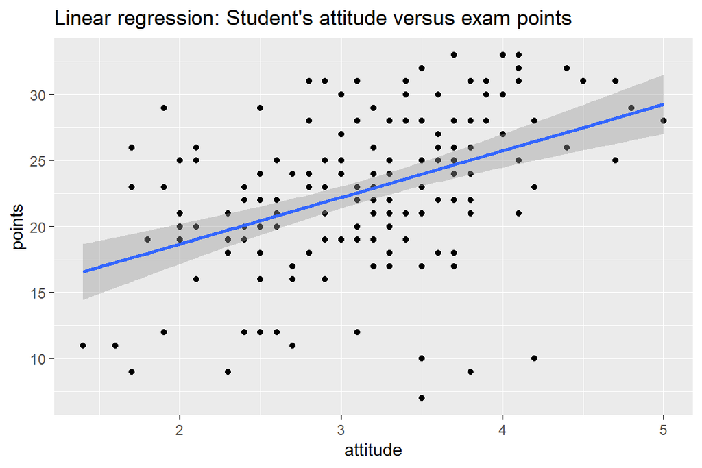

```r
# Drawing the regression line
p1 <- ggplot(students2014, aes(x = attitude, y = points))
p2 <- p1 + geom_point()
p3 <- p2 + geom_smooth(method = "lm")
p4 <- p3 + ggtitle("Linear regression: Student's attitude versus exam points")
p4
```